# Statistics 1

Making sense of data through key concepts.

## Types of Data

- **Qualitative (Categorical)**: Classifications or labels (e.g., Gender: Male or Female).
- **Quantitative**: Numerical measurements.
  - **Discrete**: Whole numbers (e.g., number of pets in a household).
  - **Continuous**: Any value in a range (e.g., height).

```python
# Titanic DataFrame
df
```

|  | survived | pclass | sex | age | sibsp | parch | fare | embarked | class | who | adult_male | deck | embark_town | alive | alone |
| --- | --- | --- | --- | --- | --- | --- | --- | --- | --- | --- | --- | --- | --- | --- | --- |
| 0 | 0 | 3 | male | 22.0 | 1 | 0 | 7.2500 | S | Third | man | True | NaN | Southampton | no | False |
| 1 | 1 | 1 | female | 38.0 | 1 | 0 | 71.2833 | C | First | woman | False | C | Cherbourg | yes | False |
| 2 | 1 | 3 | female | 26.0 | 0 | 0 | 7.9250 | S | Third | woman | False | NaN | Southampton | yes | True |
| 3 | 1 | 1 | female | 35.0 | 1 | 0 | 53.1000 | S | First | woman | False | C | Southampton | yes | False |
| 4 | 0 | 3 | male | 35.0 | 0 | 0 | 8.0500 | S | Third | man | True | NaN | Southampton | no | True |
| ... | ... | ... | ... | ... | ... | ... | ... | ... | ... | ... | ... | ... | ... | ... | ... |
| 886 | 0 | 2 | male | 27.0 | 0 | 0 | 13.0000 | S | Second | man | True | NaN | Southampton | no | True |
| 887 | 1 | 1 | female | 19.0 | 0 | 0 | 30.0000 | S | First | woman | False | B | Southampton | yes | True |
| 888 | 0 | 3 | female | NaN | 1 | 2 | 23.4500 | S | Third | woman | False | NaN | Southampton | no | False |
| 889 | 1 | 1 | male | 26.0 | 0 | 0 | 30.0000 | C | First | man | True | C | Cherbourg | yes | True |
| 890 | 0 | 3 | male | 32.0 | 0 | 0 | 7.7500 | Q | Third | man | True | NaN | Queenstown | no | True |

891 rows × 15 columns

```python
'''
Categorical: city in which the passanger embarked:
    * C = Cherbourg
    * Q = Queenstown
    * S = Southampton
'''
np.unique(df.dropna()['embarked'])
```

```
array(['C', 'Q', 'S'], dtype=object)
```

```python
# Continuous: age
df['age'].values[:10]
```

```
array([22., 38., 26., 35., 35., nan, 54.,  2., 27., 14.])
```

## Central Tendency Measures

- Help you find the middle.
- **Mean (µ)**: Sum of data (ΣX) divided by number of data points (N).
  - $\mu = \frac{\sum{X}}{N} = \frac{1}{N}\sum{X}$
- **Median**:
  - Middle value in an ordered dataset.
  - Useful when data is skewed (e.g. salaries).
- **Mode**:
  - Most frequent value.
  - Useful for categorial variables.

```python
# Mean age
f"Mean age: {np.mean(df['age']):.1f} years"
```

```
'Mean age: 29.7 years'
```

```python
# Median age
f"Median age: {np.median(df['age'].dropna())} years"
```

```
'Median age: 28.0 years'
```

```python
# Embarked mode
f"Embarked mode: {df['embarked'].mode()[0]} years"
```

```
'Embarked mode: S years'
```

```python
# Embarked counts
unique, counts = np.unique(df['embarked'].dropna(), return_counts=True)
list(zip(unique, counts))
```

```
[('C', 168), ('Q', 77), ('S', 644)]
```

## Dispersion Measures

- Range: Difference between the maximum and minimum values.
- Variance: How data deviates from the mean.
  - $\sigma^2 = \frac{\sum{(X - \mu)^2}}{N} = \frac{1}{N}\sum{(X - \mu)^2}$
- Standard Deviation (σ): How data deviates from the mean.
  - $\sigma = \sqrt{\frac{\sum{(X - \mu)^2}}{N}}$

```python
# Age range
print(f"Min: {np.min(df['age'])} years")
print(f"Max: {np.max(df['age'])} years")
print(f"Range: {np.max(df['age']) - np.min(df['age']):.1f} years")
```

```
Min: 0.42 years
Max: 80.0 years
Range: 79.6 years
```

```python
# Age std
print(f"Std: {np.std(df['age']):.1f} years")
```

```
Std: 14.5 years
```

## Correlation

- Pearson's correlation coefficient (r): Linear relationship between variables.
- Range: -1 to 1.
  - Closer to 1 means strong correlation.
  - Closer to -1 means strong inverse correlation.
  - Close to 0 means there is nothing.
- Note: Correlation ≠ Causation!

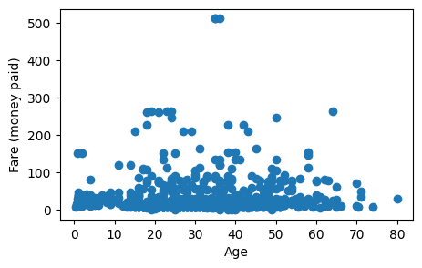

```python
# Age vs Fare
plt.figure(figsize=(5, 3))
plt.scatter(df['age'], df['fare'])
plt.xlabel('Age')
plt.ylabel('Fare (money paid)')
plt.show()
```

```python
# Age and Fair correlation
corr = np.corrcoef(df.dropna()['age'], df.dropna()['fare'])[0, 1]
f"Age and Fare correlation: {corr:.1f}"
```

```
'Age and Fare correlation: -0.1'
```

```python
# Adult male and survival
pd.DataFrame(
    df.dropna().groupby(['adult_male', 'survived']).size(),
    columns=['size'])
```

| adult_male | survived | size |
| --- | --- | --- |
| False | 0 | 6 |
|  | 1 | 89 |
| True | 0 | 53 |
|  | 1 | 34 |

```python
# Adult male and Survived have kind of inverse correlation
corr = np.corrcoef(df.dropna()['adult_male'].astype(bool), df.dropna()['survived'])[0, 1]
f"Adult male and Survived correlation: {corr:.1f}"
```

```
'Adult male and Survived correlation: -0.6'
```

## Summary

- Variables: Qualitative (M/F), Discrete (1, 2...), Continuous (0.01, 0.02...1...).
- Central tendency measures: Mean, Median, Mode.
- Dispersion measures: Range, Variance, Std.
- Correlation: [-1, 1]